title: “Milestone 2” author: “Nilson Palma, Michelle Zhen Huang” date: “2025-11-09” output: html_document: default pdf_document: default —

# Scenario 1: Infectious disease outbreak (simulated) in California

The sim_novelid_CA.csv file and sim_novelid_LACounty.csv file together represent simulated morbidity for the entire state of California. While it’s certainly possible for data from different sources to adhere to a format standard, one of the challenges of working with secondary data is that it often does not work out that way. Therefore to prepare each dataset (milestone #3) so that they can be combined into one, whole state, dataset you will need to do the following:

Morbidity datasets (from CA and LA County) Recode column names, values, or formats that are in discordant (dates, etc) Combine morbidity datasets into a single dataset Select demographic and geographic strata (s) of interest Aggregate the data into a new dataframe to include only one row per strata of interest Population dataset Recode values to be consistent with morbidity datasets so they can be joined Select demographic or geogrphic strata(s) of interest Create a rate metric and summarize to include only one row per strata of interest

###For all scenarios, please turn in an html document created from an Rmd or Qmd with the following components: Subset rows or columns, as needed Create new variables needed for analysis (minimum 2) New variables should be created based on existing columns; for example Calculating a rate Combining character strings Aggregation Clean variables needed for analysis (minimum 2) #Examples: Recode invalid values Handle missing data Recode categories Data re-structured as needed (aggregated/summarized and/or pivoted) Data dictionary based on clean dataset (minimum 4 data elements), including: Variable name Data type Description One or more tables with descriptive statistics for 4 data elements Html output that is professionally prepared for presentation Only the necessary information is outputted (you should suppress, for example, entire data frame outputs) Use of headers and sub headers to create an organized document

```r
library(janitor)
library(tidyverse)
library(dplyr)
library(readr)
library(aweek)
library(kableExtra)
library(here) #install if you don't have
```

```r
getwd()
```

```
## [1] "/Users/nilso/Desktop/R studio/PHW251/group4/infectious_disease_outbreak/reports"
```

```r
setwd("../outbreak_data")

ca_pop <- read_csv(here("outbreak_data", "ca_pop_2023.csv"))
sim_novelid_ca <- read_csv(here("outbreak_data", "sim_novelid_CA.csv"))
sim_novelid_la <- read_csv(here("outbreak_data", "sim_novelid_LACounty.csv"))

sim_novelid_ca <- sim_novelid_ca %>% clean_names()
sim_novelid_la <- sim_novelid_la %>% clean_names()

# Standardize naming and select for columns
simca1 <- sim_novelid_ca %>%
  select(
    county,
    age_cat,
    sex,
    race_eth = race_ethnicity,
    dt_diagnosis,
    time_int,
    new_infections,
    cumulative_infected,
    new_severe,
    cumulative_severe
  )

simla1 <- sim_novelid_la %>%
  mutate(county = "Los Angeles") %>%
  select(
    county,
    age_cat = age_category,
    sex,
    race_eth,
    dt_diagnosis = dt_dx,
    new_infections = dx_new,
    cumulative_infected = infected_cumulative,
    new_severe = severe_new,
    cumulative_severe = severe_cumulative
  )

simca1 <- simca1 %>% drop_na()
simla1 <- simla1 %>% drop_na()


str(simca1)
```

```
## tibble [98,952 × 10] (S3: tbl_df/tbl/data.frame)
##  $ county             : chr [1:98952] "Alameda County" "Alameda County" "Alameda County" "Alameda County" ...
##  $ age_cat            : chr [1:98952] "0-17" "0-17" "0-17" "0-17" ...
##  $ sex                : chr [1:98952] "FEMALE" "FEMALE" "FEMALE" "FEMALE" ...
##  $ race_eth           : num [1:98952] 1 1 1 1 1 1 1 1 1 1 ...
##  $ dt_diagnosis       : Date[1:98952], format: "2023-05-29" "2023-06-05" ...
##  $ time_int           : num [1:98952] 202322 202323 202324 202325 202326 ...
##  $ new_infections     : num [1:98952] 6 1 2 10 19 25 23 18 22 35 ...
##  $ cumulative_infected: num [1:98952] 6 7 9 19 38 63 86 104 126 161 ...
##  $ new_severe         : num [1:98952] 0 0 1 0 0 0 0 0 0 0 ...
##  $ cumulative_severe  : num [1:98952] 0 0 1 1 1 1 1 1 1 1 ...
```

```r
str(simla1)
```

```
## tibble [1,736 × 9] (S3: tbl_df/tbl/data.frame)
##  $ county             : chr [1:1736] "Los Angeles" "Los Angeles" "Los Angeles" "Los Angeles" ...
##  $ age_cat            : chr [1:1736] "0-17" "0-17" "0-17" "0-17" ...
##  $ sex                : chr [1:1736] "FEMALE" "FEMALE" "FEMALE" "FEMALE" ...
##  $ race_eth           : chr [1:1736] "White, Non-Hispanic" "White, Non-Hispanic" "White, Non-Hispanic" "White, Non-Hispanic" ...
##  $ dt_diagnosis       : chr [1:1736] "29MAY2023" "05JUN2023" "12JUN2023" "19JUN2023" ...
##  $ new_infections     : num [1:1736] 15 17 23 51 67 75 106 83 91 173 ...
##  $ cumulative_infected: num [1:1736] 15 32 55 106 173 248 354 437 528 701 ...
##  $ new_severe         : num [1:1736] 0 0 0 0 0 0 0 1 0 0 ...
##  $ cumulative_severe  : num [1:1736] 0 0 0 0 0 0 0 1 1 1 ...
```

```r
simla1 <- simla1 %>%
  mutate(dt_diagnosis = dmy(dt_diagnosis))

set_week_start(7)
# CDC Has a Sunday start date
## https://www.epirhandbook.com/en/new_pages/dates.html#dates_epi_wks

simca2 <- simca1 %>%
  mutate(
    year = substr(time_int, 1, 4),   # Extract 2023
    week = substr(time_int, 5, 6),    # Extract 22–52
    cdc_week = aweek::get_date(week = week, year = year)
  ) %>%
  select(-year, -week)

simla2 <- simla1 %>%
  mutate(
    cdc_week = get_date(
      week = isoweek(dt_diagnosis),
      year = year(dt_diagnosis)
    )
  )

# Convert race numeric to named factor
simca3 <- simca2 %>%
  mutate(
    race_eth = recode_factor(race_eth,
                             `1` = "White, Non-Hispanic",
                             `2` = "Black, Non-Hispanic",
                             `3` = "American Indian or Alaska Native, Non-Hispanic",
                             `4` = "Asian, Non-Hispanic",
                             `5` = "Native Hawaiian or Pacific Islander, Non-Hispanic",
                             `6` = "Multiracial (two or more of above races), Non-Hispanic",
                             `7` = "Hispanic (any race)",
                             `9` = "Unknown"
    )
  ) %>%
  select(-time_int)

# Convert race (already character) to factor
simla3 <- simla2 %>%
  mutate(race_eth = factor(race_eth))


sim_all <- bind_rows(simca3, simla3)
```

```r
str(ca_pop)
```

```
## spc_tbl_ [90,132 × 6] (S3: spec_tbl_df/tbl_df/tbl/data.frame)
##  $ county               : chr [1:90132] "Alameda" "Alameda" "Alameda" "Alameda" ...
##  $ health_officer_region: chr [1:90132] "Bay Area" "Bay Area" "Bay Area" "Bay Area" ...
##  $ age_cat              : chr [1:90132] "0-4" "0-4" "0-4" "0-4" ...
##  $ sex                  : chr [1:90132] "FEMALE" "FEMALE" "FEMALE" "FEMALE" ...
##  $ race7                : chr [1:90132] "WhiteTE NH" "WhiteTE NH" "WhiteTE NH" "WhiteTE NH" ...
##  $ pop                  : num [1:90132] 2008 2128 2142 2057 1965 ...
##  - attr(*, "spec")=
##   .. cols(
##   ..   county = col_character(),
##   ..   health_officer_region = col_character(),
##   ..   age_cat = col_character(),
##   ..   sex = col_character(),
##   ..   race7 = col_character(),
##   ..   pop = col_double()
##   .. )
##  - attr(*, "problems")=<externalptr>
```

```r
# Standardize naming and select for columns
ca_pop1 <- ca_pop %>%
  select(
    county,
    age_cat,
    sex,
    race_eth = race7,
    pop
  )
str(ca_pop1)
```

```
## tibble [90,132 × 5] (S3: tbl_df/tbl/data.frame)
##  $ county  : chr [1:90132] "Alameda" "Alameda" "Alameda" "Alameda" ...
##  $ age_cat : chr [1:90132] "0-4" "0-4" "0-4" "0-4" ...
##  $ sex     : chr [1:90132] "FEMALE" "FEMALE" "FEMALE" "FEMALE" ...
##  $ race_eth: chr [1:90132] "WhiteTE NH" "WhiteTE NH" "WhiteTE NH" "WhiteTE NH" ...
##  $ pop     : num [1:90132] 2008 2128 2142 2057 1965 ...
```

```r
unique(ca_pop1$race_eth)
```

```
## [1] "WhiteTE NH" "Black NH"   "AIAN NH"    "Asian NH"   "NHPI NH"
## [6] "MR NH"      "Hispanic"
```

```r
#Standardize race_eth
ca_pop2<- ca_pop1 %>%
  mutate(
    race_eth = recode_factor(race_eth,
                             "WhiteTE NH" = "White, Non-Hispanic",
                             "Black NH" = "Black, Non-Hispanic",
                             "AIAN NH" = "American Indian or Alaska Native, Non-Hispanic",
                             "Asian NH" = "Asian, Non-Hispanic",
                             "NHPI NH" = "Native Hawaiian or Pacific Islander, Non-Hispanic",
                             "MR NH" = "Multiracial (two or more of above races), Non-Hispanic",
                             "Hispanic" = "Hispanic (any race)"
    )
  )


#reclassify age_cat to 0-17 to match sim_novelid_ca dataset, and aggregate population data

ca_pop3 <- ca_pop2 %>%
  mutate(age_cat = case_when(
    age_cat %in% c("0-4", "5-11", "12-17") ~ "0-17",
    TRUE ~ age_cat
  )) %>%
  group_by(county, age_cat, sex, race_eth) %>%
  summarise(pop = sum(pop, na.rm = TRUE)) %>%
  ungroup()

#Remove "county" in county column to have data sets match for County column
sim_all1 <- sim_all %>%
  mutate(
    county = str_to_title(str_remove(county, " County$")),  # remove trailing " County"
    county = str_trim(county)
  )

ca_pop4 <- ca_pop3 %>%
  mutate(
    county = str_to_title(str_trim(county))
  )

#combine sim_all with ca_pop data set
sim_pop <- sim_all1 %>%
  left_join(ca_pop4,
            by = c("county", "age_cat", "sex", "race_eth"))

sim_pop_clean <- sim_pop %>%
  select(
    county,
    age_cat,
    sex,
    race_eth,
    new_infections,
    cumulative_infected,
    new_severe,
    cumulative_severe,
    pop
  )


#combining rows (with dt_diagnosis and cdc_week not included):
sim_combined <- sim_pop_clean %>%
  group_by(county, age_cat, sex, race_eth) %>%
  summarise(
    new_infections = sum(new_infections, na.rm = TRUE),
    cumulative_infected = sum(cumulative_infected, na.rm = TRUE),
    new_severe = sum(new_severe, na.rm=TRUE),
    cumulative_severe = sum(cumulative_severe, na.rm =TRUE),
    pop = sum(pop, na.rm = TRUE)
  ) %>%
  ungroup()
```

```r
#create new variables for proportions and prevalence of both infected and severe
sim_combined_var <- sim_combined %>%
  mutate(
    incidence_prop = new_infections / pop,
    prevalence_infected = cumulative_infected / pop,
    inc_severe_prop = new_severe / pop,
    prev_severe = cumulative_severe /pop
  )


#summary table
summary_table <- sim_combined_var %>%
  summarise(
    `Total Infections` = sum(new_infections, na.rm = TRUE),
    `Mean New Infections` = mean(new_infections, na.rm = TRUE),
    `Total Severe Cases` = sum(new_severe, na.rm = TRUE),
    `Mean Cumulative Infected` = mean(cumulative_infected, na.rm = TRUE),
  )

kable(summary_table,
      caption = "Summary of Infection Metrics",
      digits = 2)
```

Summary of Infection Metrics

| Total Infections | Mean New Infections | Total Severe Cases | Mean Cumulative Infected |
| --- | --- | --- | --- |
| 4549583 | 1400.73 | 126926 | 22085.61 |

```r
str(sim_pop)
```

```
## tibble [100,688 × 11] (S3: tbl_df/tbl/data.frame)
##  $ county             : chr [1:100688] "Alameda" "Alameda" "Alameda" "Alameda" ...
##  $ age_cat            : chr [1:100688] "0-17" "0-17" "0-17" "0-17" ...
##  $ sex                : chr [1:100688] "FEMALE" "FEMALE" "FEMALE" "FEMALE" ...
##  $ race_eth           : Factor w/ 7 levels "White, Non-Hispanic",..: 1 1 1 1 1 1 1 1 1 1 ...
##  $ dt_diagnosis       : Date[1:100688], format: "2023-05-29" "2023-06-05" ...
##  $ new_infections     : num [1:100688] 6 1 2 10 19 25 23 18 22 35 ...
##  $ cumulative_infected: num [1:100688] 6 7 9 19 38 63 86 104 126 161 ...
##  $ new_severe         : num [1:100688] 0 0 1 0 0 0 0 0 0 0 ...
##  $ cumulative_severe  : num [1:100688] 0 0 1 1 1 1 1 1 1 1 ...
##  $ cdc_week           : Date[1:100688], format: "2023-05-28" "2023-06-04" ...
##  $ pop                : num [1:100688] 34155 34155 34155 34155 34155 ...
```

```r
head(sim_pop)
```

```
## # A tibble: 6 × 11
##   county  age_cat sex   race_eth dt_diagnosis new_infections cumulative_infected
##   <chr>   <chr>   <chr> <fct>    <date>                <dbl>               <dbl>
## 1 Alameda 0-17    FEMA… White, … 2023-05-29                6                   6
## 2 Alameda 0-17    FEMA… White, … 2023-06-05                1                   7
## 3 Alameda 0-17    FEMA… White, … 2023-06-12                2                   9
## 4 Alameda 0-17    FEMA… White, … 2023-06-19               10                  19
## 5 Alameda 0-17    FEMA… White, … 2023-06-26               19                  38
## 6 Alameda 0-17    FEMA… White, … 2023-07-03               25                  63
## # ℹ 4 more variables: new_severe <dbl>, cumulative_severe <dbl>,
## #   cdc_week <date>, pop <dbl>
```

```r
unique(sim_pop$cdc_week)
```

```
##  [1] "2023-05-28" "2023-06-04" "2023-06-11" "2023-06-18" "2023-06-25"
##  [6] "2023-07-02" "2023-07-09" "2023-07-16" "2023-07-23" "2023-07-30"
## [11] "2023-08-06" "2023-08-13" "2023-08-20" "2023-08-27" "2023-09-03"
## [16] "2023-09-10" "2023-09-17" "2023-09-24" "2023-10-01" "2023-10-08"
## [21] "2023-10-15" "2023-10-22" "2023-10-29" "2023-11-05" "2023-11-12"
## [26] "2023-11-19" "2023-11-26" "2023-12-03" "2023-12-10" "2023-12-17"
## [31] "2023-12-24"
```

```r
# rate per 100k
fun <- sim_pop %>%
  mutate(
    weekly_incidence_per100k = (new_infections / pop) * 100000,
    weekly_severe_per100k = (new_severe / pop) * 100000
  )

head(fun) %>%
  select(county, age_cat, cdc_week, new_infections, pop, weekly_incidence_per100k)
```

```
## # A tibble: 6 × 6
##   county  age_cat cdc_week   new_infections   pop weekly_incidence_per100k
##   <chr>   <chr>   <date>              <dbl> <dbl>                    <dbl>
## 1 Alameda 0-17    2023-05-28              6 34155                    17.6
## 2 Alameda 0-17    2023-06-04              1 34155                     2.93
## 3 Alameda 0-17    2023-06-11              2 34155                     5.86
## 4 Alameda 0-17    2023-06-18             10 34155                    29.3
## 5 Alameda 0-17    2023-06-25             19 34155                    55.6
## 6 Alameda 0-17    2023-07-02             25 34155                    73.2
```

Looking at whole California over time - Aggregate by week - All ages, all races, all sexes

Viewing the dataset you can see peak months are August, Sept, Oct

```r
fun1 <- fun %>%
  group_by(cdc_week) %>%
  summarise(
    total_cases = sum(new_infections, na.rm = TRUE),
    total_pop = sum(pop, na.rm = TRUE),
    total_severe = sum(new_severe, na.rm = TRUE)
  ) %>%
  mutate(
    ci_per100k = (total_cases / total_pop) * 100000,
    ci_severe100k = (total_severe / total_pop) *100000
  )
## Peak months are August, September, October
```

Look at age group over time - there are differences in rates between age groups - At a quick glance severe CI is greater in 65+ most weeks - to make it easier to see what’s going on for total CI I’m going to graph it

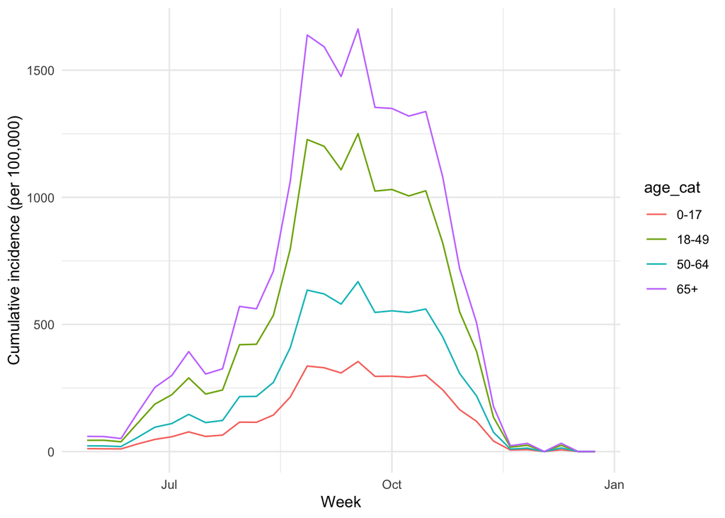

```r
fun2 <- fun %>%
  group_by(cdc_week, age_cat) %>%
  summarise(
    total_cases = sum(new_infections, na.rm = TRUE),
    total_pop = sum(pop, na.rm = TRUE),
    total_severe = sum(new_severe, na.rm = TRUE)
  ) %>%
  mutate(
    ci_per100k = (total_cases / total_pop) * 100000,
    ci_severe100k = (total_severe / total_pop) *100000
  )

ggplot(fun2,
       aes(x = cdc_week,
           y = ci_per100k,
           color = age_cat)) +
  geom_line() +
  labs(
    x = "Week",
    y = "Cumulative incidence (per 100,000)"
  )+
  theme_minimal()
```

Looking at race/ethnicity over time - graph shows there are differences in CI between race/ethnicity - American Indian/Alaskan Native are observed to have the greatest peaks in CI

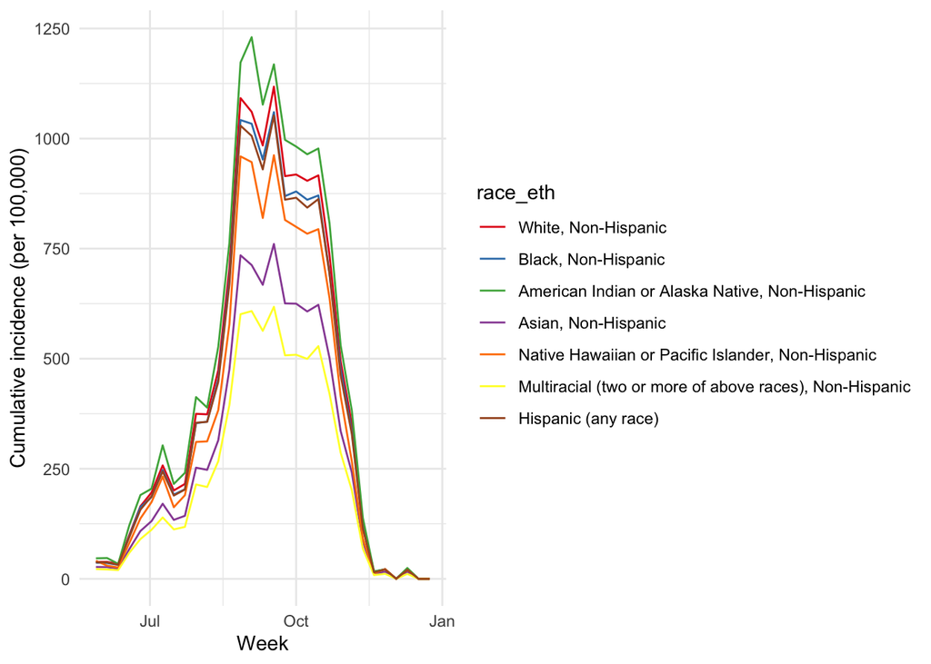

```r
fun3 <- fun %>%
  group_by(cdc_week, race_eth) %>%
  summarise(
    total_cases = sum(new_infections, na.rm = TRUE),
    total_pop = sum(pop, na.rm = TRUE),
    total_severe = sum(new_severe, na.rm = TRUE)
  ) %>%
  mutate(
    ci_per100k = (total_cases / total_pop) * 100000,
    ci_severe100k = (total_severe / total_pop) *100000
  )

ggplot(fun3,
       aes(x = cdc_week,
           y = ci_per100k,
           color = race_eth)) +
  geom_line() +
  scale_color_brewer(palette = "Set1") +
  labs(
    x = "Week",
    y = "Cumulative incidence (per 100,000)"
  )+
  theme_minimal()
```